# Final Visualizations

Anna Calderon

2023-10-31

## Figure 1

OUD estimates for the NYS counties

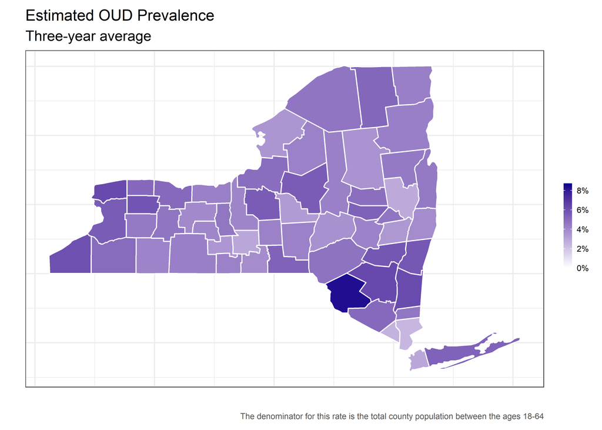

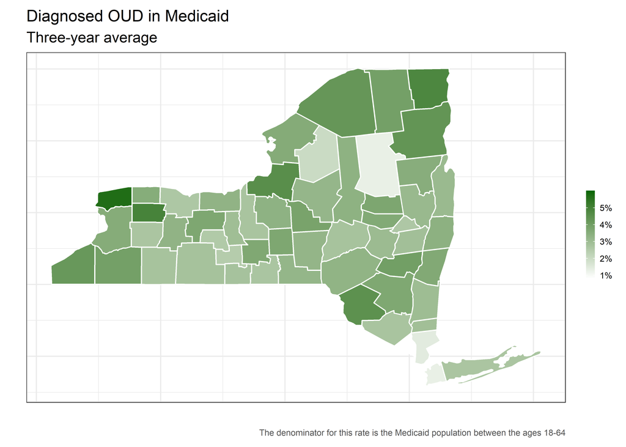

## Figure 2

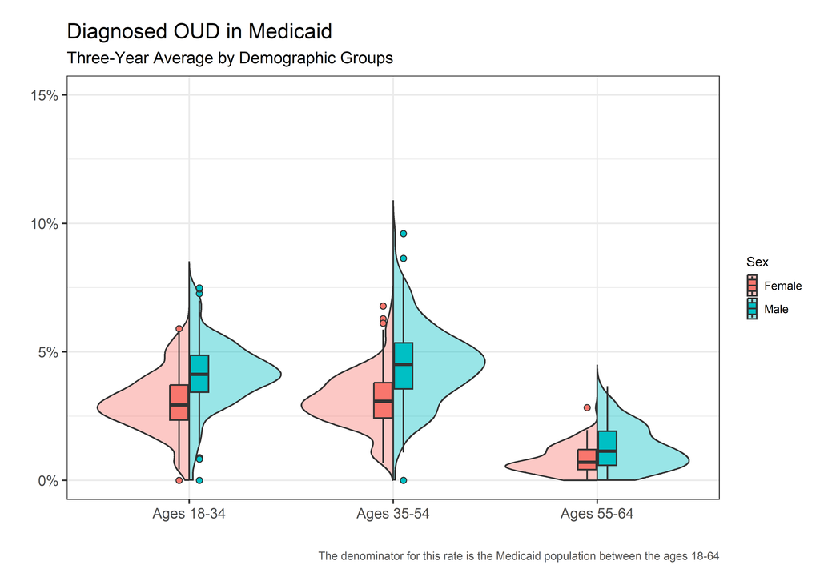

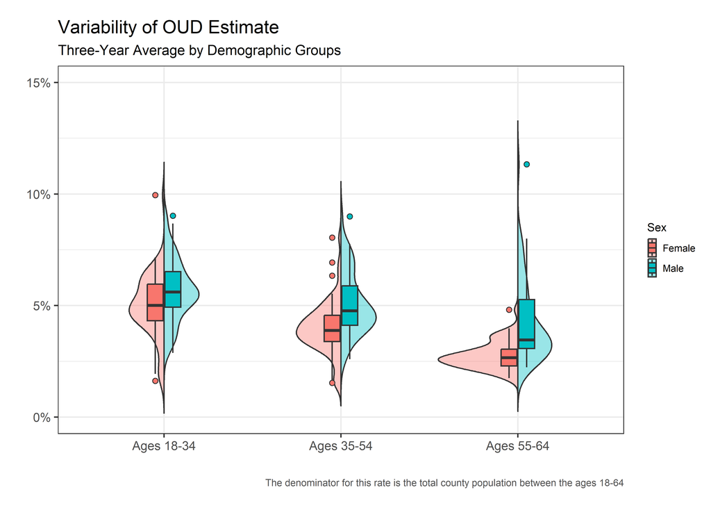

## Figure 3 Counties trends

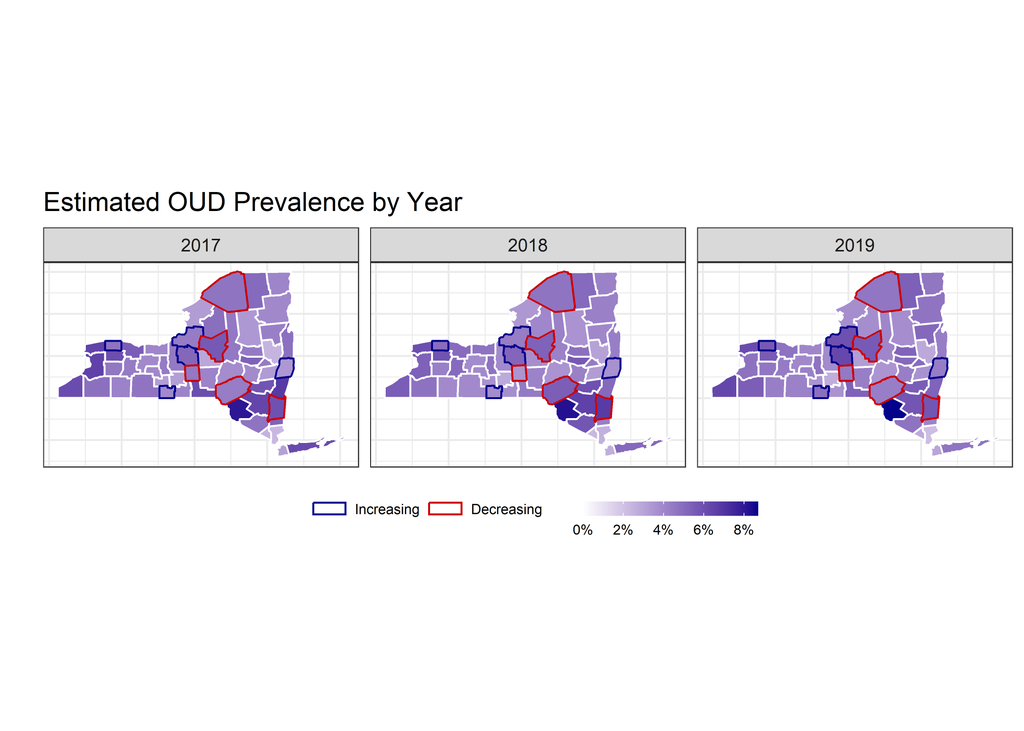

## Figure 4 Using this Figure, we would like to show how under-diagnosed OUD were accounted for in our OUD estimate. We hypothesize that high overdose deaths are due to high untreated OUD.

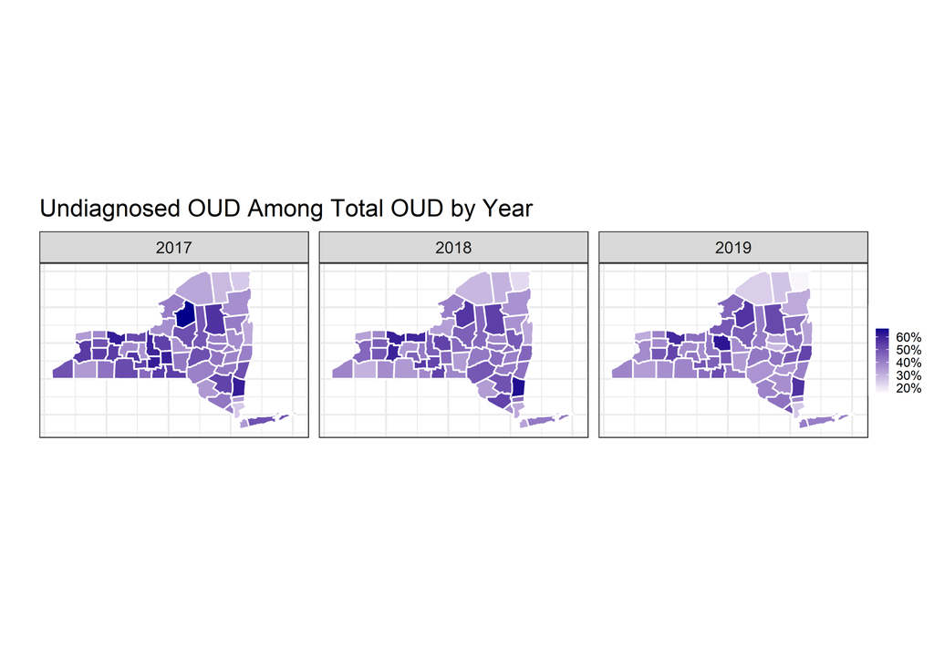

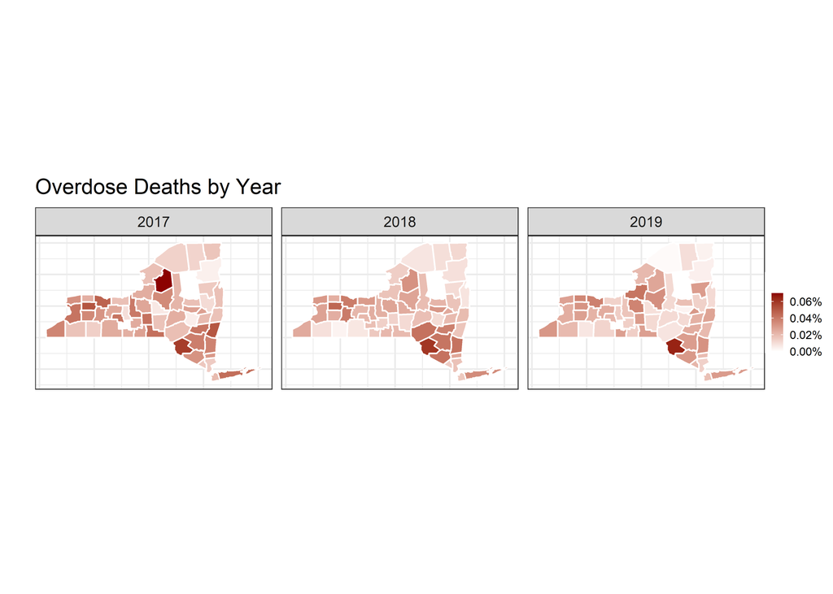

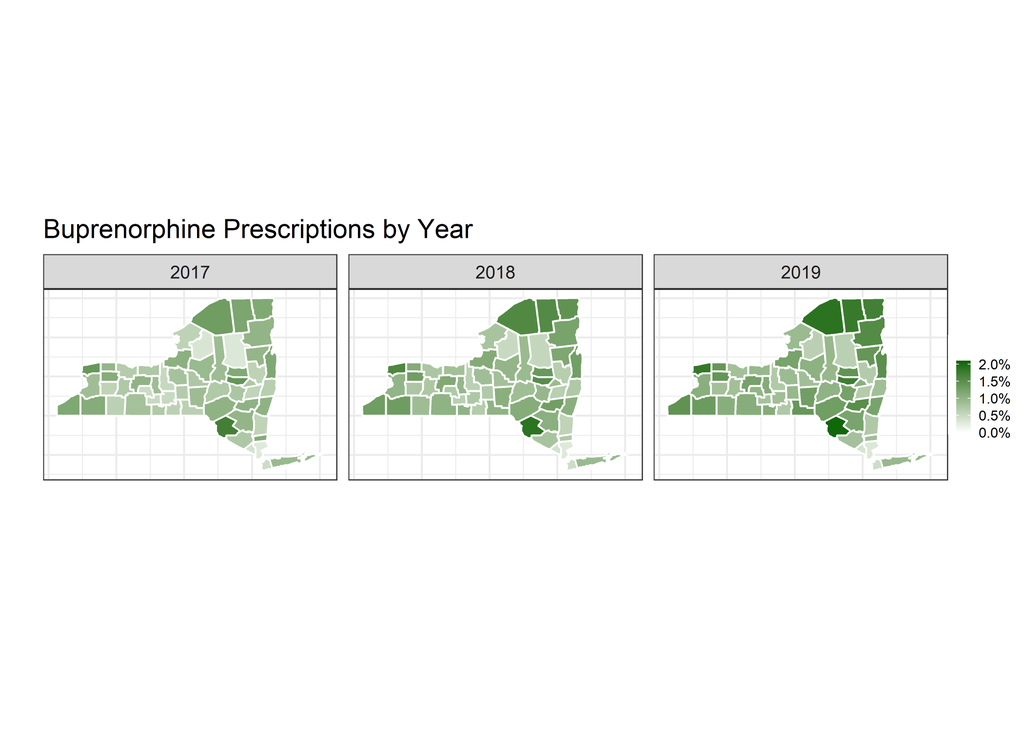

##Figure 5 The percentage under-diagnosed based on our estimate is plotted against income.

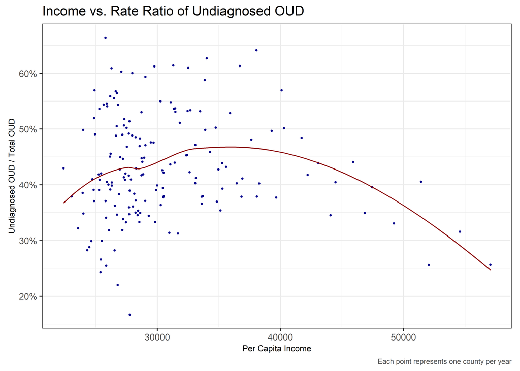

[figure not shown]

#Supplement ## Figure S1 In a county without a severe issue of under-diagnosis OR a fast-growing OUD epidemic (faster than the treatment effort), we expect the drop of overdose fatality as a response to increase in treatment effort (such as what we found in these counties below).

[figure not shown]

## Figure S2 The following counties show another trend: growing overdose fatality, despite increases in treatment effort. This suggests 1) treatment is not keeping pace with the OUD epidemic in the county; 2) under-diagnosis. Both could be happening at the same time.

[figure not shown]

##Figure S3 Undiagnosed OUD is not distributed evenly across demographic groups.

[output not shown]

[output cut: 199 more lines]